# Psych 10 Project: Milestone 3

Daniel Chen, Adamari Alamillo, and Marilyn Frank

NOTE: Submit this file as a .Rmd file on Canvas.

This is Milestone 3 of your project. The goals of Milestone 3 of your project are to:

- Test your hypothesis using the appropriate statistical tests.
- Estimate how large the effect is by using one of the following: effect size, confidence intervals, Bayes factors
- Visualize your results, including one figure that summarizes your primary result.
- Interpret your results in writing.

DUE DATE: 3/11 @ 10:30 AM.

# Environment set up

**q1** Set up your environment by loading the needed packages and saving the file path(s) to your data as values in your environment.

```r
#Libaries
#Load the packages you need here

library(tidyverse)
library(readxl)

article_data_file <- 'https://raw.githubusercontent.com/googletrends/data/master/Documenting_Hate_latest.csv'

nypd_data_file_2017 <- 'https://raw.githubusercontent.com/shyue/HateCrimeReports/master/nypd2017.csv'
nypd_data_file_2018 <- 'https://raw.githubusercontent.com/shyue/HateCrimeReports/master/nypd2018.csv'


#Files
# e.g., data_file <- "path"
```

# Read in your data

**q2** Read in your data file using the appropriate function.

```r
article_data <- read_csv(article_data_file)
nypd_data_2017 <- read_csv(nypd_data_file_2017)
nypd_data_2018 <- read_csv(nypd_data_file_2018)
article_data <- article_data %>%
  select(City, Title) %>%
  filter(City == "New York")

set.seed(42)
```

```r
#function for filtering data for category based on keywords
hatecrime_category <- function(title) {
  sapply(title, function(title) {
  race_words <- c(
    'Arab',
    'Asian',
    'Black',
    'Hispanic', 'Latino', 'Latina', 'Mexican',
    'Multi-racial', 'Multiracial',
    'Native American', 'Native-American',
    'White', 'Caucasian',
    'race', 'racism', 'racist', 'immigrant'
  )

  religious_words <- c(
    'Catholic',
    'Islam', 'Muslim',
    'Christian',
    'Jewish', 'antisemit',
    'religion', 'religious'
  )

  sexorie_words <- c(
    'Lesbian',
    'Gay',
    #'Transgender',
    'Trans',
    'LGBTQ',
    'queer',
    'homo' #'homophobic', 'homophobia',
    #'transphobic', 'transphobia'
  )

  race_count <- 0
  religious_count <- 0
  sexorie_count <- 0

  #counting occurrences
  for (word in race_words){
    race_count = race_count + str_count(tolower(title), tolower(word))
  }

  for (word in religious_words){
    religious_count = religious_count + str_count(tolower(title), tolower(word))
  }

  for (word in sexorie_words){
    sexorie_count = sexorie_count + str_count(tolower(title), tolower(word))
  }

  #removing words that are not the maximum number of keywords
  type <- c("Race", "Sexual Orientation", "Religious Affiliation")

  if (religious_count < race_count | religious_count < sexorie_count) {
    type <- type[type != "Religious Affiliation"]
  }

  if (race_count < religious_count | race_count < sexorie_count) {
    type <- type[type != "Race"]
  }

  if (sexorie_count < religious_count | race_count > sexorie_count) {
    type <- type[type != "Sexual Orientation"]
  }

  if (length(type) == 0 | (sexorie_count==0 & race_count==0 & religious_count==0)){
    return("None")
  }
  #pick random value out of the top (max) choices if there's a tie
  return(sample(type,1))
  })}
```

```r
article_data <- article_data %>%
  mutate(Category = hatecrime_category(Title)) %>%
  filter(Category!="None") %>%
  select(-City, -Title)
```

```r
nypd_data <-c()
for (curr_column in colnames(nypd_data_2017)){

  #Race categories
  if (curr_column == "ANTI-ARAB" |
      curr_column == "ANTI-ASIAN" |
      curr_column == "ANTI-BLACK" |
      curr_column == "ANTI-HINDU" |
      curr_column == "ANTI-HISPANIC" |
      curr_column == "ANTI-OTHER ETHNICITY/NATIONAL ORIGIN/ANCESTRY" |
      curr_column == "ANTI-WHITE") {
    #append an observation based on the last row (total row)
    for (i in 1:as.numeric(nypd_data_2017[nrow(nypd_data_2017),curr_column])){
      nypd_data <- c(nypd_data, "Race")
    }
  }

  #Sexual Orientation categories
  if (curr_column == "ANTI-FEMALE HOMOSEXUAL (LESBIAN)" |
      curr_column == "ANTI-LGBT" |
      curr_column == "ANTI-MALE HOMOSEXUAL (GAY)" |
      curr_column == "ANTI-TRANSGENDER") {
    #append an observation based on the last row (total row)
    for (i in 1:as.numeric(nypd_data_2017[nrow(nypd_data_2017),curr_column])){
      nypd_data <- c(nypd_data, "Sexual Orientation")
    }
  }

  #Religion categories
  if (curr_column == "ANTI-CATHOLIC" |
      curr_column == "ANTI-ISLAMIC" |
      curr_column == "ANTI-JEWISH" |
      curr_column == "ANTI-MULTI-RELIGIOUS GROUPS" |
      curr_column == "ANTI-RELIGIOUS PRACTICE, GENERALLY") {
    #append an observation based on the last row (total row)
    for (i in 1:as.numeric(nypd_data_2017[nrow(nypd_data_2017),curr_column])){
      nypd_data <- c(nypd_data, "Religious Affiliation")
    }
  }


}
```

```r
for (curr_column in colnames(nypd_data_2018)){

  #Race categories
  if (curr_column == "Anti-Arab" |
      curr_column == "Anti-Asian" |
      curr_column == "Anti-Black" |
      curr_column == "Anti-Hispanic" |
      curr_column == "Anti-Multi-Racial Groups" |
      curr_column == "Anti-Other Ethnicity/National Origin" |
      curr_column == "Anti-White") {
    #append an observation based on the last row (total row)
    for (i in 1:as.numeric(nypd_data_2018[nrow(nypd_data_2018),curr_column])){
      nypd_data <- c(nypd_data, "Race")
    }
  }

  #Sexual Orientation categories
  if (curr_column == "Anti-Female Homosexual (Lesbian)" |
      curr_column == "Anti-Male Homosexual (Gay)" |
      curr_column == "Anti-Transgender") {
    #append an observation based on the last row (total row)
    for (i in 1:as.numeric(nypd_data_2018[nrow(nypd_data_2018),curr_column])){
      nypd_data <- c(nypd_data, "Sexual Orientation")
    }
  }

  #Religion categories
  if (curr_column == "Anti-Catholic" |
      curr_column == "Anti-Islamic (Muslim)" |
      curr_column == "Anti-Jewish" |
      curr_column == "Anti-Mormon" |
      curr_column == "Anti-Other Christian" |
      curr_column == "Anti-Other Religion") {
    #append an observation based on the last row (total row)
    for (i in 1:as.numeric(nypd_data_2018[nrow(nypd_data_2018),curr_column])){
      nypd_data <- c(nypd_data, "Religious Affiliation")
    }
  }


}
```

```r
nypd_data <- data.frame("Category" = nypd_data)
```

```r
nypd_data <- data.frame(table(nypd_data$Category))
article_data <- data.frame(table(article_data$Category))

NYPD_RaceCount <- (nypd_data %>% filter(Var1=='Race'))$Freq
NYPD_SexOriCount <- (nypd_data %>% filter(Var1=='Sexual Orientation'))$Freq
NYPD_ReligionCount <- (nypd_data %>% filter(Var1=='Religious Affiliation'))$Freq

Article_RaceCount <- (article_data %>% filter(Var1=='Race'))$Freq
Article_SexOriCount <- (article_data %>% filter(Var1=='Sexual Orientation'))$Freq
Article_ReligionCount <- (article_data %>% filter(Var1=='Religious Affiliation'))$Freq
```

In Milestone 2, you cleaned your data. Below, copy and paste any chunks of code you used to clean your data for Milestone 2. If you need to perform additional data cleaning as advised by your TA, please do so.

# Hypothesis testing

In Milestone 1, you identified your hypothesis for your project question. Please restate your hypothesis below (it’s okay if it changed *prior* to hypothesis testing):

*The reports of each category of hate crime will be dependent on whether the reports are from the NYPD or if they are from media reports, and that the counts for each category will be different.*

**q3** What is the null hypothesis?

*The null hypothesis is that the reports of each category of hate crime will be independent on whether the reports are from the NYPD or the media.*

**q4** Test your hypothesis using the appropriate statistical tests. Points to consider: Are your variables continuous or categorical? If your variables are continuous, are they normally distributed? If one or more of your variables is categorical, how many categories are there?

```r
#Preparing Counts
Race_HateCrime <- c(Article_RaceCount, NYPD_RaceCount)
Religion_HateCrime <- c(Article_ReligionCount, NYPD_ReligionCount)
SexOri_HateCrime <- c(Article_SexOriCount, NYPD_SexOriCount)


#Creating matrixes for each category
All_matrix = matrix(c(Race_HateCrime, Religion_HateCrime, SexOri_HateCrime), nrow=3, byrow=TRUE)
rownames(All_matrix) = c('Race', 'Religion', 'SexOri')
colnames(All_matrix) = c('Media', 'NYPD')

Race_matrix = matrix(c(Race_HateCrime, Religion_HateCrime+SexOri_HateCrime), nrow=2, byrow=TRUE)
rownames(Race_matrix) = c('Race', 'Other')
colnames(Race_matrix) = c('Media', 'NYPD')

Religion_matrix = matrix(c(Religion_HateCrime, Race_HateCrime+SexOri_HateCrime), nrow=2, byrow=TRUE)
rownames(Religion_matrix) = c('Religion', 'Other')
colnames(Religion_matrix) = c('Media', 'NYPD')

SexOri_matrix = matrix(c(SexOri_HateCrime, Religion_HateCrime+Race_HateCrime), nrow=2, byrow=TRUE)
rownames(SexOri_matrix) = c('SexOri', 'Other')
colnames(SexOri_matrix) = c('Media', 'NYPD')


chisq.test(All_matrix, correct=FALSE)
```

```
##
##  Pearson's Chi-squared test
##
## data:  All_matrix
## X-squared = 122.43, df = 2, p-value < 2.2e-16
```

```r
chisq.test(Race_matrix, correct=FALSE)
```

```
##
##  Pearson's Chi-squared test
##
## data:  Race_matrix
## X-squared = 28.399, df = 1, p-value = 9.873e-08
```

```r
chisq.test(Religion_matrix, correct=FALSE)
```

```
##
##  Pearson's Chi-squared test
##
## data:  Religion_matrix
## X-squared = 119.44, df = 1, p-value < 2.2e-16
```

```r
chisq.test(SexOri_matrix, correct=FALSE)
```

```
##
##  Pearson's Chi-squared test
##
## data:  SexOri_matrix
## X-squared = 46.39, df = 1, p-value = 9.689e-12
```

```r
Race_matrix
```

```
##       Media NYPD
## Race    233  181
## Other   335  496
```

```r
SexOri_matrix
```

```
##        Media NYPD
## SexOri   186  110
## Other    382  567
```

```r
Religion_matrix
```

```
##          Media NYPD
## Religion   149  386
## Other      419  291
```

**q5** In writing, interpret the results of your hypothesis test(s). Move beyond the p-value and where the test is “significant”. For example, if you compared means, describe the size of the means in relation to each other; if you use a chi-square test, create a contingency table and describe the relative proportions; if you used regression, interpret the meaning of the intercept and slope(s). Overall, demonstrate that you understand what the test is estimating.

*Using a chi-square test, we tested whether the reports of each category of hate crime would depend on whether it was a Media report or a report to the NYPD. We used a chi-square test to compare the counts of each hate crime group under each type of report (e.g. race hate crime vs other hate crime under media reports and nypd reports) to the expected counts under the null hypothesis that hate crime and report type are independent. Results of the test indicated that it was unlnikely that race, religious, and sexual orientation related hate crimes were independent of type of reports (Race:28.399(df=1), Religion:119.44(df=1), Sexual Orientation:46.39(df=1), p<0.001 for all three tests). Specifically, the media covered race and sexual orientation related hate crimes more than actual NYPD reports, while also underreporting the number of religion related hate crimes. Therefore, we reject the null hypothesis that the counts of each hate crime category are independent of the type of report (either media or NYPD)*

# Effect size

**q6** Estimate how large the effect(s) are. Regardless of whether your hypothesis test was “significant”, quantify the size of the effect using measure of effect sizes (e.g., odds ratio or standardized residual for chi-square test; strength of the correlation coefficient; standardized mean difference [cohen’s d] for comparing means; standardized beta and/or R-squared for linear regression), confidence intervals, and/or Bayes factors. Interpret the the effect size in writing.

```r
odds_race_media = Article_RaceCount/(Article_ReligionCount+Article_SexOriCount)
odds_race_nypd = NYPD_RaceCount/(NYPD_ReligionCount+NYPD_SexOriCount)
odds_race = odds_race_media/odds_race_nypd
odds_race
```

```
## [1] 1.905962
```

```r
odds_religion_media = Article_ReligionCount/(Article_RaceCount+Article_SexOriCount)
odds_religion_nypd = NYPD_ReligionCount/(NYPD_RaceCount+NYPD_SexOriCount)
odds_religion = odds_religion_media/odds_religion_nypd
odds_religion
```

```
## [1] 0.2680883
```

```r
odds_sexori_media = Article_SexOriCount/(Article_RaceCount+Article_ReligionCount)
odds_sexori_nypd = NYPD_SexOriCount/(NYPD_RaceCount+NYPD_ReligionCount)
odds_sexori = odds_sexori_media/odds_sexori_nypd
odds_sexori
```

```
## [1] 2.509805
```

*We computed the odds-ratio for the probability of race hate crimes being reported in the media versus the probability of race hate crimes being reported to the NYPD, and the media was 1.9 times more likely to report race hate crimes*

*We computed the odds-ratio for the probability of religious hate crimes being reported in the media versus the probability of religious hate crimes being reported to the NYPD, and the media was 0.268 times as likely to report religious hate crimes*

*We computed the odds-ratio for the probability of sexual orientation hate crimes being reported in the media versus the probability of sexual orientation hate crimes being reported to the NYPD, and the media was 2.5 times more likely to report sexual orientation hate crimes*

**q7**

Use `ggplot()` to visualize your results. Include at least one plot that graphically depicts the primary result of your hypothesis test. Show the variability in the data: if you have a categorical variable, use a boxplot or violin plot; if you have continuous variables, show both the scatter plot (geom_point) and the appropriate trendline.

Make your primary plot “presentation quality”: 1) Provide a title that describes the main take-away of the plot (i.e., Black individuals are disproportionately searched by the police *NOT* Proportions of Black and White individual searched by the police), 2) Label your axes, 3) Adjust the axis text if necessary by changing the “breaks” using one of the scale_ functions (e.g., scale_x_continuous, scale_x_discrete), 4) if one of your variables is categorical, order the data logically using fct_reorder(), 5) Consider adding reference lines using geom_vline or geom_hline.

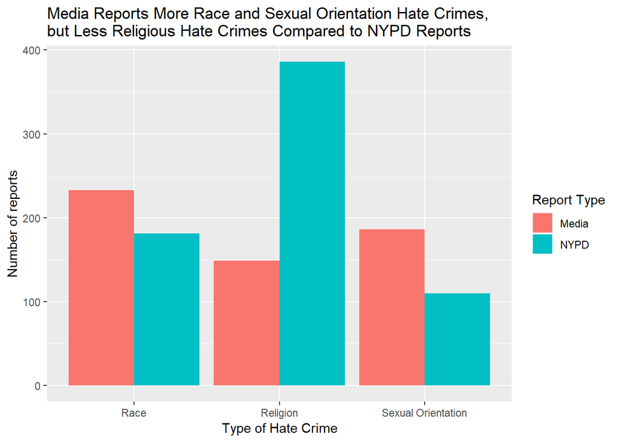

```r
graph_counts = c(Article_RaceCount, Article_ReligionCount, Article_SexOriCount, NYPD_RaceCount, NYPD_ReligionCount, NYPD_SexOriCount)
graph_hatetype = c('Race', 'Religion', 'Sexual Orientation', 'Race', 'Religion', 'Sexual Orientation')
graph_mediatype = c('Media', 'Media', 'Media', 'NYPD', 'NYPD', 'NYPD')
graph_df <- data.frame(graph_counts, graph_hatetype, graph_mediatype)

graph_df %>%
  ggplot() + aes(x=graph_hatetype, y=graph_counts) + geom_bar(aes(fill=graph_mediatype), stat="identity", position="dodge") +
  labs(x="Type of Hate Crime", y="Number of reports", title="Media Reports More Race and Sexual Orientation Hate Crimes, \nbut Less Religious Hate Crimes Compared to NYPD Reports", fill="Report Type")
```

**Team member contributions** Briefly describe each member’s contribution below. We all met together and worked on the same computer at the same time. Thus, our contributions were all equal.